# Chapter 5: Time Value of Money

FINA 3000 · Business Finance I · Class 5

Dr. Justin Mohr

September 8, 2026

## PV and FV

- Every problem in this chapter is one of these two, rearranged

$$\begin{array}{rlll}
FV_{N} = & PV\left(1+I\right)^{N} \\
PV = & \frac{FV_{N}}{\left(1+I\right)^{N}}
\end{array}$$

- Growing forward multiplies by $\left(1+I\right)$; discounting back divides by it

## Annuity

- When equal payments are made at fixed intervals, we call them annuities!
- The primary type is an ordinary annuity
  - Payments are made at the end of the period
- Very common: auto loans, mortgages, etc.

## FV of an annuity

What is the FV of an annuity that pays $1,200 for 3 years if the rate is 3%

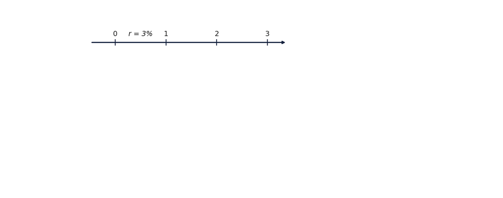

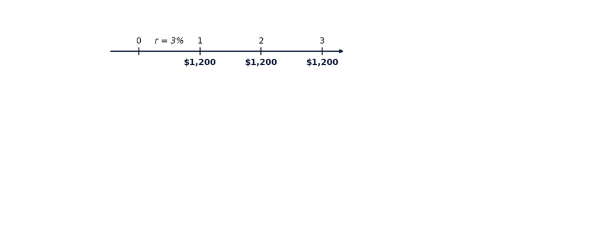

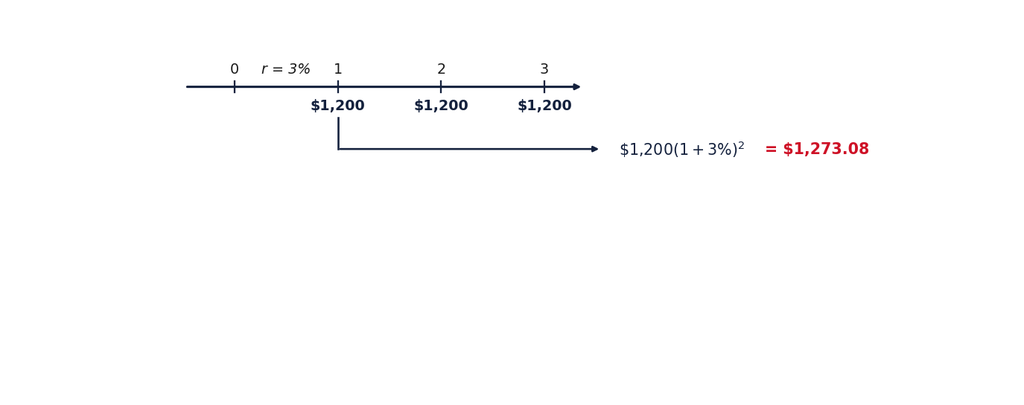

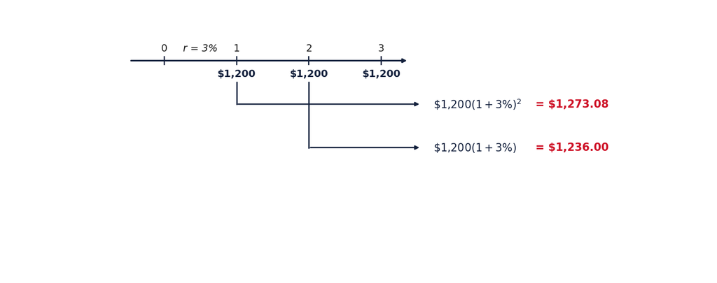

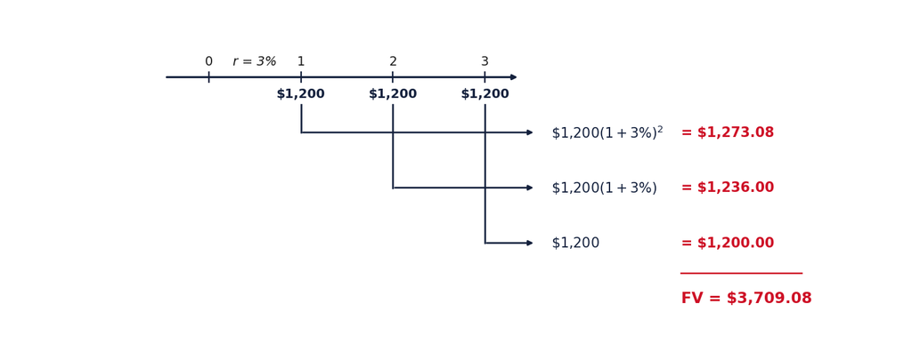

## Ordinary Annuity vs. Annuity Due

Ordinary Annuity

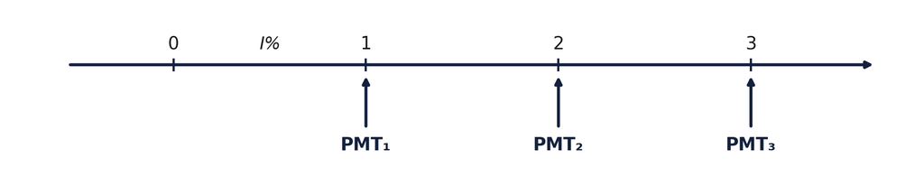

Annuity Due

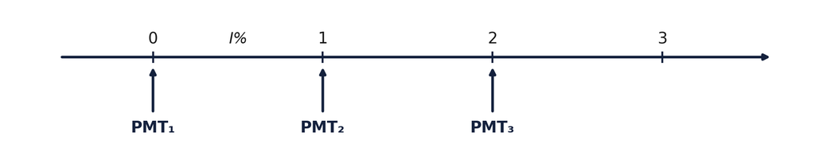

## Graduation trip

You decide to save for a graduation trip. You will save $1,000 per year starting today.

How much will you have at the end of 2 years if you earn no interest? How much if you earn 6%?

With no interest, $3,000. At 6%, $3,183.60.

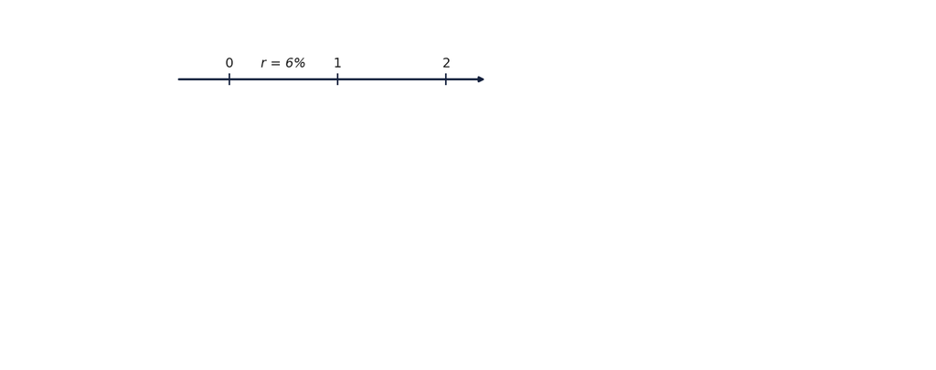

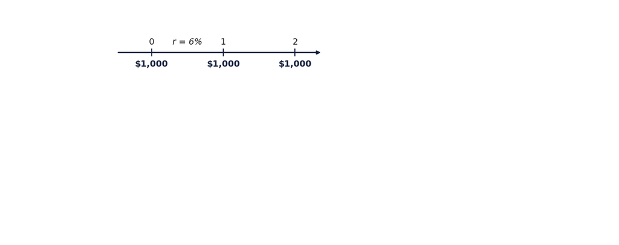

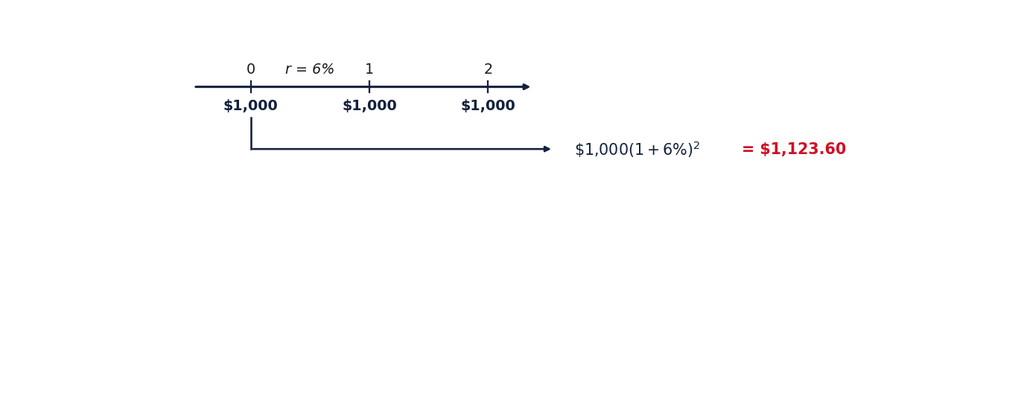

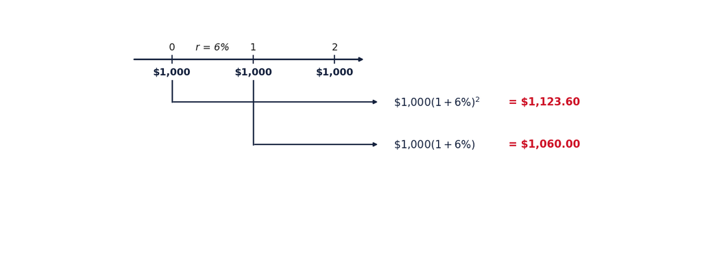

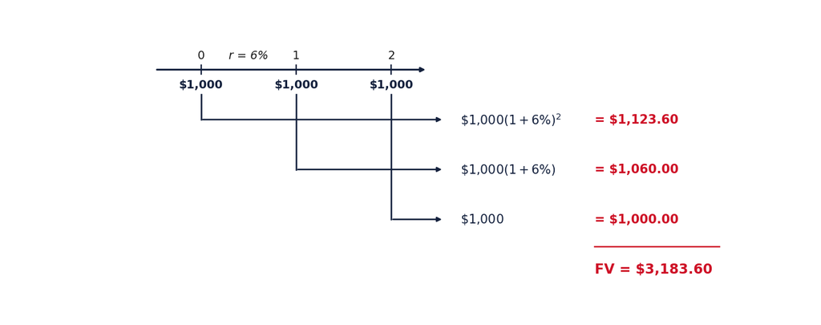

## Saving for the trip

How much do you need to invest today to have $3,000 four years from today if you earn 10%?

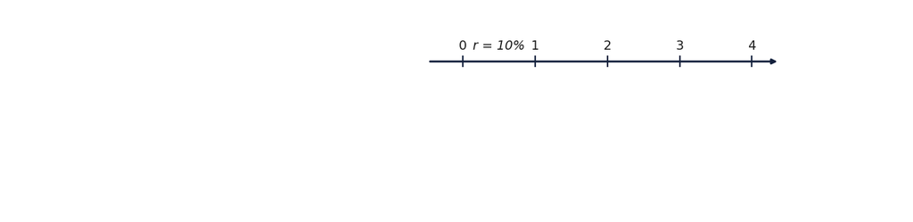

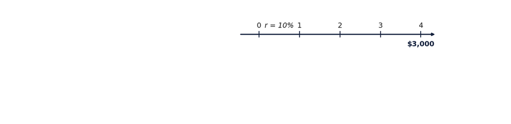

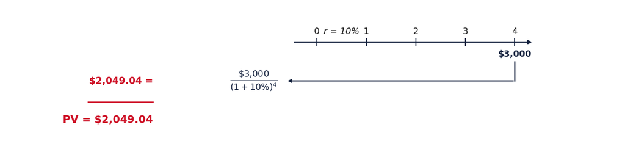

## TVM Setup

- Today, we will discuss how to use the financial calculator
- 5 main pieces that we need to get from EVERY TVM problem to use them
  - N
  - I/Y
  - PV
  - PMT
  - FV

## Positive or Negative

- The calculator runs an algorithm. It will matter what sign you make the CFs
- General rule: If you are writing a check, it is negative. If you are getting money, then it is positive
- “You invest”, “You deposit”,etc
  - Negative
- Loans: When you get a mortgage or car loan that money is given to you
  - PV: positive, Payment: negative

## Saving

You are saving 500 dollars every year starting today and invest in a fund that earns 7% yearly. How much should you expect to have at the end of 3 years?

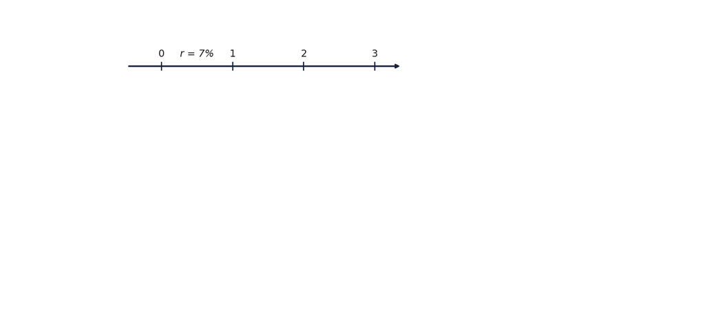

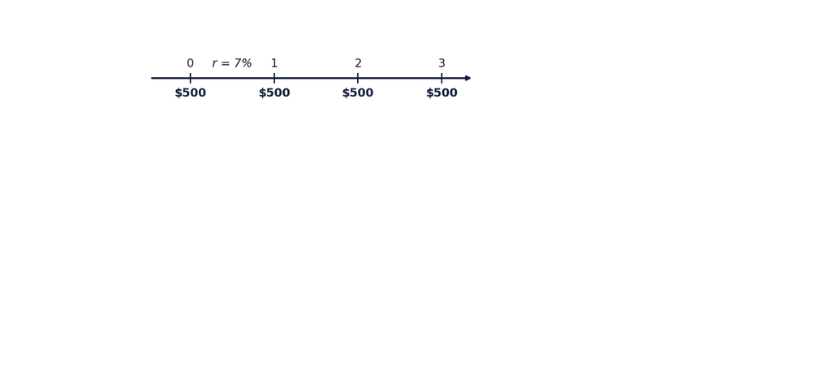

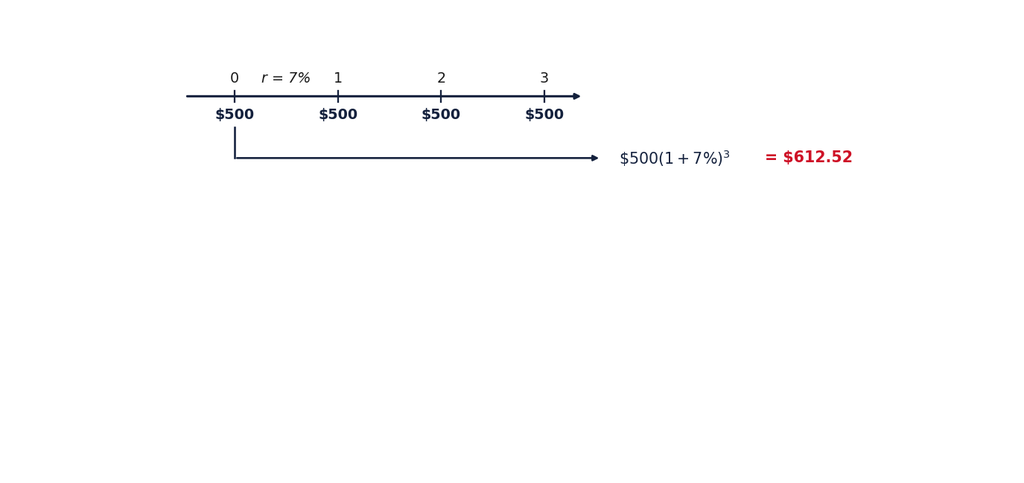

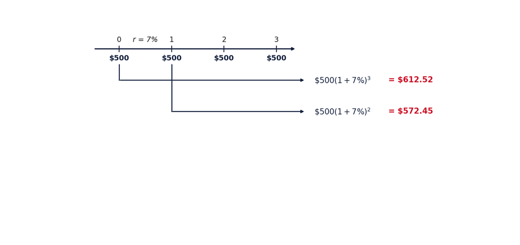

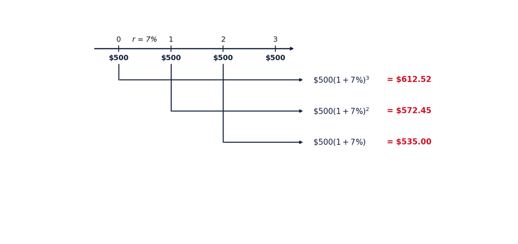

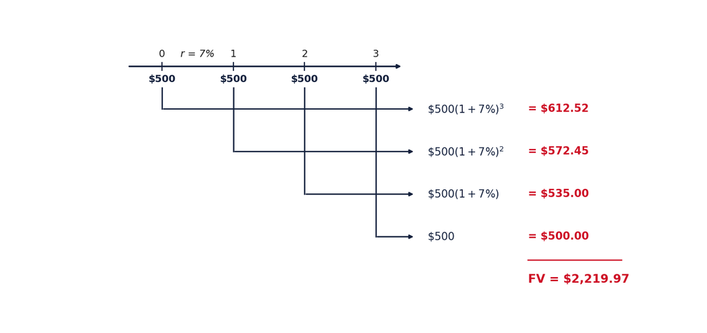

## Saving on the calculator

The same problem as the slide before: $500 a year starting today, 7%, three years.

N3I/Y7PV-500PMT-500FV?

CPT FV2,219.97

The deposit you make **today** is already in the account, so it is the **PV**. The three that follow are the **PMT**, and there are three periods left for them: **N = 3**.

## FV Discussion

Your mom calls you. She explains that she want to invest in a 3 year CD that pays 3% interest. Interest is paid once a year. She knows that you are taking finance classes and asks you, “How much money will I have in 3 years if I invest $1,500 dollars today?”

N3I/Y3%PV-1,500PMT0FV?

CPT FV1639.09

## PV

How much do you need to invest today to have $5K three years from today if the discount rate is 5%?

N3I/Y5%PV?PMT0FV5000

CPT PV-4319.19

## Value of calculator

- Using just math, it would be very difficult to solve for N or I

$$F{V}_{N}=PV{\left( 1+I \right)}^{N}$$

- Using you calculator is straight forward
- We solve for either I or N

## Solving for I

Your mom calls you. She wants to save for a trip in 5 years. She has $3,000 dollars to invest today, and $1,000 dollars every year after that to invest. She will need $10,000 dollars. What interest rate will she require?

N5I/Y?PV-3,000PMT-1,000FV10,000

CPT I/Y7.13%

## Solving for N

You are investing $1,000 per year at 7%. You will make the first investment today. How many years will it take for you to save $10,000?

N?I/Y7PV-1,000PMT-1,000FV10,000

CPT N6.84

## Consumer Installment Loans

- You will experience these in your life
  - Auto loans, mortgages, personal loans
- We will walk through the structure and the repayment terms of these

## Buying a car

You walk into the dealership and want to buy an $18.2K car.

You are trading in a car worth $10K. This means we have to borrow $8.2K.

What is the payment, at 7% for 5 years?

N5I/Y7PV8,200PMT?FV0

CPT PMT-1,999.90

## Amortization

Your payment is $1,999.90 a year and the rate is 7%.

**Principal times rate** is the part of each payment that goes to **interest**. The remainder lowers the **principal**.

Amortization schedule: what each payment pays for, and what is still owed at the end of the year

| Year | Beginning balance | Payment | Interest | Principal repaid | Ending balance |
| --- | --- | --- | --- | --- | --- |
| 1 | $8,200.00 | $1,999.90 | $574.00 | $1,425.90 | $6,774.10 |
| 2 | $6,774.10 | $1,999.90 | $474.19 | $1,525.71 | $5,248.39 |
| 3 | $5,248.39 | $1,999.90 | $367.39 | $1,632.51 | $3,615.87 |
| 4 | $3,615.87 | $1,999.90 | $253.11 | $1,746.79 | $1,869.09 |
| 5 | $1,869.09 | $1,999.90 | $130.84 | $1,869.06 | $0.02 |
| Total |  | $9,999.50 | $1,799.52 | $8,199.98 |  |

The balance does not quite reach zero: **$0.02 is still owing**. That is the fractional pennies we rounded away in taking the payment to $1,999.90. A lender simply increases the final payment to clear it.

## Paying it off sooner

The same loan: $8,200 borrowed at **7%** over **5 years**, paying **$1,999.90** a year.

What if you want the loan gone sooner? How much interest do you save if you pay $1,000 more each year?

Amortization schedule: what each payment pays for, and what is still owed at the end of the year

| Year | Beginning balance | Payment | Interest | Principal repaid | Ending balance |
| --- | --- | --- | --- | --- | --- |
| 1 | $8,200.00 | $2,999.90 | $574.00 | $2,425.90 | $5,774.10 |
| 2 | $5,774.10 | $2,999.90 | $404.19 | $2,595.71 | $3,178.39 |
| 3 | $3,178.39 | $2,999.90 | $222.49 | $2,777.41 | $400.97 |
| 4 | $400.97 | $429.04 | $28.07 | $400.97 | $0.00 |
| 5 |  |  |  |  |  |
| Total |  | $9,428.74 | $1,228.74 | $8,200.00 |  |

You save **$570.78** in interest, and the loan is gone in 4 years instead of 5.

The last payment is only what is still owed, not the full instalment.

## Compounding Periods

- Interest is most commonly stated annually
  - This is the APR or annual percentage rate
- Periodic Rate: actual amount of interest charged each month.
  - APR/Periods per yr
- However almost no financial product compounds interest annually, we typically compound monthly.
- We can still do this math! We just need to make a few changes
- N
  - YR*Periods per yr
- I/Y
  - APR/Periods per yr
- PV
  - Same
- PMT
  - Same
- FV
  - Same

## Monthly to Annual Interest Rate

You borrowed $5,000 dollars for a used car. Your payment is 200 dollars a month for 72 months. What APR are they charging you?

N72I/Y?PV5,000PMT-200FV0

CPT I/Y3.71

Is that our APR?

NO! That is the periodic rate! APR=3.71*12= 44.5%

## Loan Amortization

Fred wants to buy a car. The bank will lend him $40K. The loan will be amortized over 5 years. The nominal interest is 8% and interest is compounded and payments are monthly.

What is the payment?

N5*12I/Y8/12PV40KPMT?FV0

CPT PMT-811.06

## Your mortgage

You buy a house with a **$200,000** mortgage at **6%**, paid monthly over **30 years**.

What is the monthly payment?

N30*12I/Y6/12PV200,000PMT?FV0

CPT PMT-1,199.10

## An extra $500 a month

The same mortgage: **$200,000** at **6%**, and the payment you just found was **$1,199.10**.

You decide to pay **$1,699.10** instead, $500 more every month.

How much sooner is the house paid off?

N?I/Y6/12PV200,000PMT-1,699.10FV0

CPT N178.06

**178 months, just under 15 years**, against 30. The extra $500 cuts the mortgage almost exactly in half.

## Finding remaining balance

Same $200,000 mortgage at 6%.

If you make the $1,699.10 payment, what balance is left on the loan after 10 years?

N10*12I/Y6/12PV200,000PMT-1,699.10FV?

CPT FV-85,431.95

You still owe **$85,431.95**, with about 58 payments to go of the 178.

At the original $1,199.10 payment you would still owe **$167,371.62**.

## Upcoming Dates

Upcoming class dates and deadlines

| Date | Topic | Due / Notes |
| --- | --- | --- |
| Thu Sep 10 | Chapter 5: Time Value of Money | - |
| Sun Sep 13 | MindTap Ch 5 | HW DUE |
| Tue Sep 15 | Review for Test 1 | Review |
| Thu Sep 17 | Test 1 | EXAM |

**Office:** 325 Holman Hall · **Office hours:** T TH 10:50A-12:20P · jjmohr1@olemiss.edu